# Midterm

## Tim Demetriades

### AAI 646 - B - Hong Man

3/11/2022

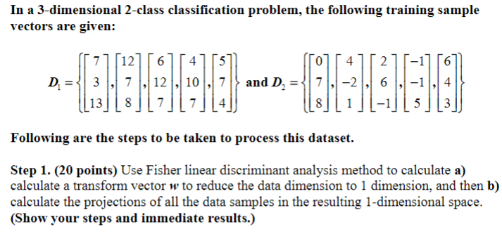

### a) Transform Vector

```python
import matplotlib.pyplot as plt
import numpy as np
from math import sqrt, exp, pi
```

```python
D1 = np.array([[7, 3, 13],
               [12, 7, 8],
               [6, 12, 7],
               [4, 10, 7],
               [5, 7, 4]])
D2 = np.array([[0, 7, 8],
               [4, -2, 1],
               [2, 6, -1],
               [-1, -1, 5],
               [6, 4, 3]])
```

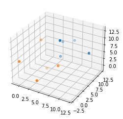

```python
fig = plt.figure()
ax = plt.axes(projection='3d')
ax.scatter3D(D1[:, 0], D1[:, 1], D1[:, 2])
ax.scatter3D(D2[:, 0], D2[:, 1], D2[:, 2])
```

First mean vector is calculated for each class.

```python
n_1 = len(D1)
n_2 = len(D2)
```

```python
mean_1 = (D1.sum(axis = 0) / len(D1)).reshape(-1, 1)
mean_2 = (D2.sum(axis = 0) / len(D2)).reshape(-1, 1)
print(f'Mean 1 = \n{mean_1}')
print(f'Mean 2 = \n{mean_2}')
```

```
Mean 1 =
[[6.8]
 [7.8]
 [7.8]]
Mean 2 =
[[2.2]
 [2.8]
 [3.2]]
```

Scatter matrices are now calculated using the means.

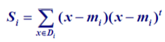

```python
scatter_matrix_1 = np.zeros([3, 3])
scatter_matrix_2 = np.zeros([3, 3])

for sample_1, sample_2 in zip(D1, D2):
    scatter_sum_1 = (sample_1.reshape(-1, 1) - mean_1) @ (sample_1.reshape(-1, 1) - mean_1).T
    scatter_sum_2 = (sample_2.reshape(-1, 1) - mean_2) @ (sample_2.reshape(-1, 1) - mean_2).T
    scatter_matrix_1 += scatter_sum_1
    scatter_matrix_2 += scatter_sum_2
```

```python
scatter_matrix_1
```

```
array([[ 38.8, -13.2,  11.8],
       [-13.2,  46.8, -27.2],
       [ 11.8, -27.2,  42.8]])
```

```python
scatter_matrix_2
```

```
array([[ 32.8,  -1.8, -20.2],
       [ -1.8,  66.8,  10.2],
       [-20.2,  10.2,  48.8]])
```

Within-class scatter matrix is now calculated by summing the two scatter matrices.

```python
s_w = scatter_matrix_1 + scatter_matrix_2
print(f'Within-class scatter matrix = \n{s_w}')
```

```
Within-class scatter matrix =
[[ 71.6 -15.   -8.4]
 [-15.  113.6 -17. ]
 [ -8.4 -17.   91.6]]
```

Transform vector is now calculated by multiplying inverse of within-class scatter matrix with the difference of the mean vectors.

```python
w = np.linalg.inv(s_w) @ (mean_1 - mean_2)
print(f'Transform vector = \n{w}')
```

```
Transform vector =
[[0.08631653]
 [0.06594255]
 [0.07037208]]
```

### b) 1D Projections

The projections, y_k, can now be found by multiplying the transpose of the transform vector by each element of the feature vector.

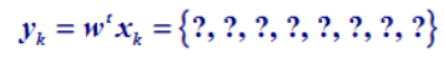

```python
D = np.concatenate((D1, D2))
D
```

```
array([[ 7,  3, 13],
       [12,  7,  8],
       [ 6, 12,  7],
       [ 4, 10,  7],
       [ 5,  7,  4],
       [ 0,  7,  8],
       [ 4, -2,  1],
       [ 2,  6, -1],
       [-1, -1,  5],
       [ 6,  4,  3]])
```

```python
y_k = []
for sample in D:
    y_k_value = w.T @ (sample.reshape(-1, 1))
    y_k.append(float(y_k_value))
```

```python
projections_class1 = y_k[0:5]
projections_class2 = y_k[5:]
print('1D Projections:')
print(f'Class 1 Projections = {projections_class1}')
print(f'Class 2 Projecitons = {projections_class2}')
```

```
1D Projections:
Class 1 Projections = [1.7168803431164408, 2.060372804759387, 1.8018142733014546, 1.4972961184200635, 1.1746687831838698]
Class 2 Projecitons = [1.0245744307906977, 0.2837531079597322, 0.4979162641311655, 0.19960130184319808, 0.9927855996612338]
```

Just for fun I decided to reconstruct the data to verify it has been projected into 1 dimension.

```python
n = len(D)
projections = np.zeros([n, 3])
for i, y_k_value in zip(range(n), y_k):
    approximation = (y_k_value * w).reshape(-1, 1)
    projections[i] = approximation.T
```

```python
print(f'Reconstructed Data = \n{projections}')
```

```
Reconstructed Data =
[[0.14819516 0.11321546 0.12082043]
 [0.17784423 0.13586623 0.14499271]
 [0.15552636 0.11881622 0.12679741]
 [0.12924141 0.09873552 0.10536784]
 [0.10139333 0.07746065 0.08266388]
 [0.08843771 0.06756305 0.07210143]
 [0.02449258 0.0187114  0.0199683 ]
 [0.0429784  0.03283387 0.0350394 ]
 [0.01722889 0.01316222 0.01404636]
 [0.08569381 0.06546681 0.06986438]]
```

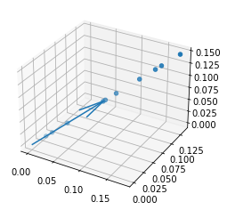

```python
fig = plt.figure()
ax = plt.axes(projection='3d')
ax.scatter3D(projections[:, 0], projections[:, 1], projections[:, 2])
plt.quiver(0, 0, 0, *w)
```

Above we can see that the data has successfully been projected into 1 dimension, with the arrow pointing in the direction of the transform vector w.

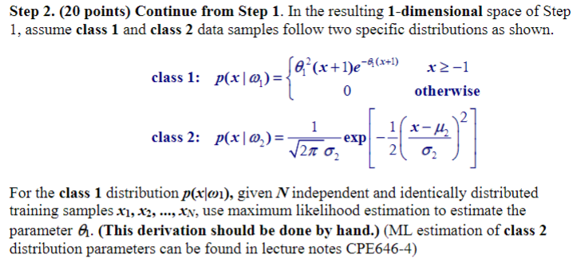

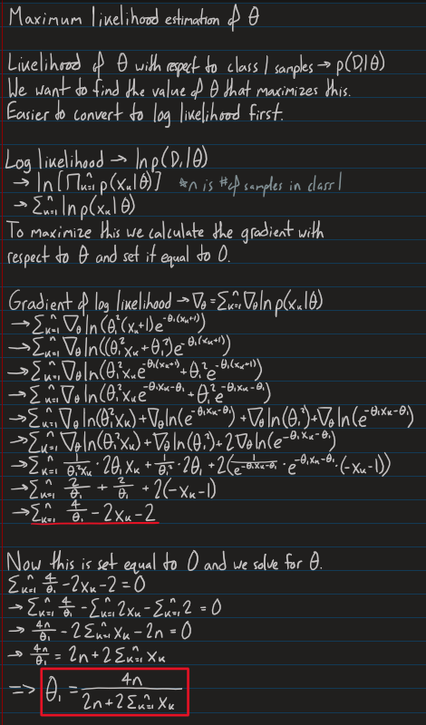

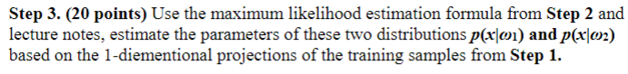

Above is the MLE formula from Step 2 for class 1. Below is the MLE formula(s) from the lecture notes for class 2 (gaussian):

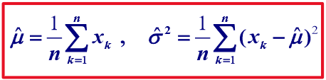

First we'll calculate theta1, the estimation for class 1.

```python
projections_class1
```

```
[1.7168803431164408,
 2.060372804759387,
 1.8018142733014546,
 1.4972961184200635,
 1.1746687831838698]
```

```python
projections_class2
```

```
[1.0245744307906977,
 0.2837531079597322,
 0.4979162641311655,
 0.19960130184319808,
 0.9927855996612338]
```

```python
theta_1 = (4 * n_1) / ((2 * n_1) + (2 * sum(projections_class1)))
```

```python
print(f'Theta_1 = {theta_1:.5f}')
```

```
Theta_1 = 0.75466
```

```python
mean = sum(projections_class2) / n_2
print(f'Mean = {mean:.5f}')
```

```
Mean = 0.59973
```

```python
std_dev_sum = 0
for projection in projections_class2:
    difference_squared = (projection - mean) ** 2
    std_dev_sum += difference_squared
std_dev = std_dev_sum / n_2
variance = sqrt(std_dev)
print(f'Standard Deviation = {std_dev:.5f}')
print(f'Variance = {variance:.5f}')
```

```
Standard Deviation = 0.12106
Variance = 0.34794
```

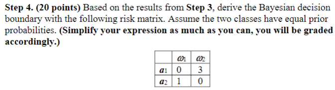

[figure not shown]

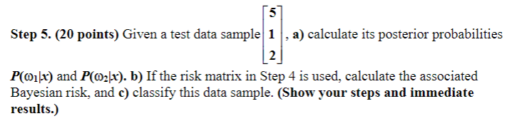

### a) Posterior Probabilities

```python
sample = np.array([5, 1, 2]).reshape(-1, 1)
sample
```

```
array([[5],
       [1],
       [2]])
```

```python
projection_1d = w.T @ sample
projection_1d
```

```
array([[0.63826935]])
```

The posterior probability can be calculated using Bayes' formula. We need the likelihoods, priors, and evidence.

```python
prior = 0.5    # assume each of the 2 classes has equal priors
```

The likelihood for each class can be calculated by using the formulas from step 2.

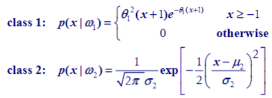

```python
likelihood_1 = float((theta_1 ** 2) * (projection_1d + 1) * exp(-1 * theta_1 * (projection_1d + 1)))
likelihood_1
```

```
0.2709899078057164
```

```python
likelihood_2 = (1 / (sqrt(2 * pi) * variance)) * (exp(-0.5 * (((float(projection_1d) - mean) / variance) ** 2)))
likelihood_2
```

```
1.1395843482056476
```

```python
evidence = (prior * likelihood_1) + (prior * likelihood_2)
evidence
```

```
0.705287128005682
```

Finally, the posterior probabilities can be calculated using Bayes' formula.

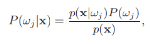

```python
posterior_1 = (likelihood_1 * prior) / evidence
posterior_2 = (likelihood_2 * prior) / evidence
print(f'Posterior Probability 1 = {posterior_1}')
print(f'Posterior Probability 2 = {posterior_2}')
```

```
Posterior Probability 1 = 0.19211318131665464
Posterior Probability 2 = 0.8078868186833453
```

As can be seen above, the posterior probablilty for class 2 is much greater than for class 1. Based on this we can assume the test sample is part of **class 2**.

### b) Bayesian Risk

Bayesian (conditional) risk can be calculated using the following:

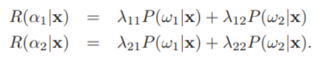

```python
loss_11 = 0
loss_21 = 1
loss_12 = 3
loss_22 = 0

risk_1 = (loss_11 * posterior_1) + (loss_12 * posterior_2)
risk_2 = (loss_21 * posterior_1) + (loss_22 * posterior_2)

print(f'Bayesian Risk 1 = {risk_1:.5f}')
print(f'Bayesian Risk 2 = {risk_2:.5f}')
```

```
Bayesian Risk 1 = 2.42366
Bayesian Risk 2 = 0.19211
```

### c) Classify this data sample

As can be seen above, the posterior probabilty for class 2 is greater than that of class 1. Additionally, the Bayesian risk associated with class 1 is greater than that of class 2.

**Since we base our classification on the class with the higher posterior probability and lower risk, we should classify this data sample as Class 2.**